# Distributional semantics as a predictor of human similarity judgments

Molly Lewis

2019-06-10

## Language and human similarity data

For each animal pair, we have human judgements of similarity along 5 dimensions ( shape, skin/texture, color) and language estimates of similarity. The human judgements of similarity come from a card sorting task and are at the group level (blind vs. sighted).

The language estimates of similarity come from word embedding models. I identified all the unique color/texture/skin words listed by participants in describing the animals, and removed a few that were obviously unrelated to teh dimension). E.g., here are the words for color:

`"white" "black" "red" "light" "gold" "blue" "brown" "dark" "yellow" "neutral" "multi" "orange"`

`"grey" "gray" "medium" "pattern" "pink" "bright" "patterns" "spots" "tan" "amber" "stripes" "tawny" "ochre"`

Then, for each animal, I created a 25-D vector, where each dimension corresponds to one of the color words. Each value corresponds to the cosine distance between the vector for that animal and the vector for that word. I then calculated the distance between each animal based on these color vectors. I did an analagous thing for the other dimensions.

```r
TAXONOMIC_DATA <- here("data/processed/animal_distances_taxonomic.csv")

taxonomic_long <- read_csv(TAXONOMIC_DATA) %>%
  rename(taxo_similarity = similarity)
```

# Wiki

```r
LANG_ANIMAL_DISTANCE_COLOR <- here("data/processed/animal_color_distances_language_wiki.csv")
LANG_ANIMAL_DISTANCE_SHAPE<- here("data/processed/animal_shape_distances_language_wiki.csv")
LANG_ANIMAL_DISTANCE_TEXTURE <- here("data/processed/animal_texture_distances_language_wiki.csv")

TIDY_HUMAN_PATH <- here("data/processed/tidy_human_data.csv")
language_data <- read_csv(LANG_ANIMAL_DISTANCE_COLOR) %>%
  left_join(read_csv(LANG_ANIMAL_DISTANCE_SHAPE), by  = c("animal1", "animal2")) %>%
  left_join(read_csv(LANG_ANIMAL_DISTANCE_TEXTURE),by  = c("animal1", "animal2"))  %>%
  mutate_if(is.numeric, ~-.x )

human_data <- read_csv(TIDY_HUMAN_PATH)
full_sim_data <- full_join(language_data, human_data, by = c("animal1", "animal2"))

human_data_wide <- human_data %>%
  unite("measure", c("participant_type", "similarity_type")) %>%
  spread(measure, human_similarity)

full_sim_data_wide <- full_join(language_data, human_data_wide,
                                by = c("animal1", "animal2"))  %>%
  full_join(taxonomic_long) %>%
  filter(animal1 < animal2)
```

Each data point here is an animal pair

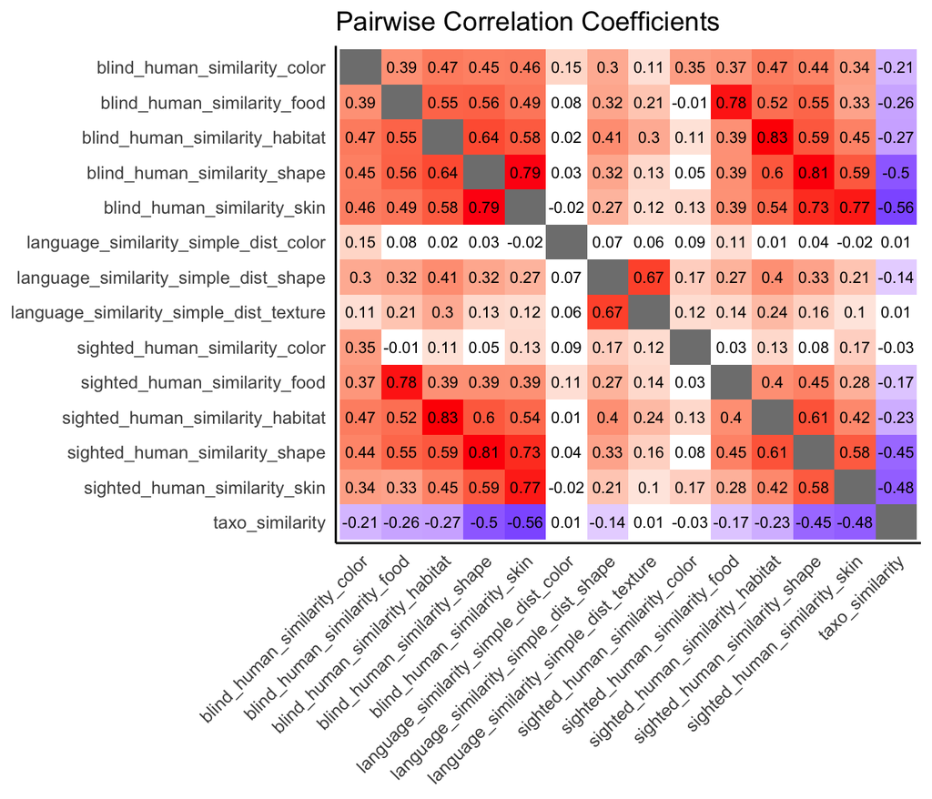

```r
plot_data <- full_sim_data_wide %>%
  select_if(is.numeric)

long_corr <- cor(plot_data,
                 use = "pairwise.complete.obs",
                 method = "spearman") %>%
  as.data.frame() %>%
  rownames_to_column("v2") %>%
  gather("v1", "estimate", -v2)

long_p <- corrplot::cor.mtest(plot_data,
                              use = "pairwise.complete.obs",
                              method = "spearman")$p %>%
  as.data.frame(row.names = names(plot_data)) %>%
  do(setNames(.,names(plot_data))) %>%
  rownames_to_column("v2") %>%
  gather("v1", "p", -v2)

corr_df <- full_join(long_corr, long_p) %>%
  mutate(estimate_char = case_when(v1 == v2 ~ "",
                                   TRUE ~ as.character(round(estimate,2))),
         estimate = case_when(v1 == v2 ~ as.numeric(NA),
                              TRUE ~ estimate),
         estimate_color = case_when(p < .05 ~ estimate, TRUE ~ 0 ))

ggplot(corr_df, aes(v1, fct_rev(v2), fill = estimate_color)) +
  geom_tile() + #rectangles for each correlation
  #add actual correlation value in the rectangle
  geom_text(aes(label = estimate_char), size=3) +
  scale_fill_gradient2(low ="blue", mid = "white", high = "red",
                       midpoint = 0, space = "Lab", guide = "colourbar",
                       name = "Pearson's r") +
  ggtitle("Pairwise Correlation Coefficients") +
  theme_classic(base_size = 12) +
  theme(axis.text.x = element_text(angle = 45, hjust = 1), #, hjust = .95, vjust = .2),
        axis.title.x=element_blank(),
        axis.title.y=element_blank(),
        axis.ticks = element_blank(),
        legend.position = "none")
```

```r
full_sim_data_wide2 <-  full_join(language_data, human_data,
                                  by = c("animal1", "animal2"))    %>%
    spread(similarity_type, human_similarity) %>%
    full_join(taxonomic_long) %>%
    filter(animal1 < animal2)

lm(human_similarity_color~ language_similarity_simple_dist_color+
    taxo_similarity  ,  data = full_sim_data_wide2 %>% mutate_if(is.numeric, scale) %>% filter(participant_type == "blind")) %>%
  summary()
```

```
##
## Call:
## lm(formula = human_similarity_color ~ language_similarity_simple_dist_color +
##     taxo_similarity, data = full_sim_data_wide2 %>% mutate_if(is.numeric,
##     scale) %>% filter(participant_type == "blind"))
##
## Residuals:
##      Min       1Q   Median       3Q      Max
## -1.19043 -0.48458 -0.06184  0.37166  3.15547
##
## Coefficients:
##                                       Estimate Std. Error t value Pr(>|t|)
## (Intercept)                            0.18756    0.03199   5.864 8.99e-09
## language_similarity_simple_dist_color  0.12045    0.03200   3.764 0.000191
## taxo_similarity                       -0.19940    0.03200  -6.230 1.11e-09
##
## (Intercept)                           ***
## language_similarity_simple_dist_color ***
## taxo_similarity                       ***
## ---
## Signif. codes:  0 '***' 0.001 '**' 0.01 '*' 0.05 '.' 0.1 ' ' 1
##
## Residual standard error: 0.6671 on 432 degrees of freedom
## Multiple R-squared:  0.1088, Adjusted R-squared:  0.1047
## F-statistic: 26.38 on 2 and 432 DF,  p-value: 1.558e-11
```

```r
lm(human_similarity_color~ language_similarity_simple_dist_color+
    taxo_similarity,  data = full_sim_data_wide2 %>% mutate_if(is.numeric, scale) %>% filter(participant_type == "sighted")) %>%
  summary()
```

```
##
## Call:
## lm(formula = human_similarity_color ~ language_similarity_simple_dist_color +
##     taxo_similarity, data = full_sim_data_wide2 %>% mutate_if(is.numeric,
##     scale) %>% filter(participant_type == "sighted"))
##
## Residuals:
##     Min      1Q  Median      3Q     Max
## -1.0470 -0.7732 -0.4904  0.1773  4.2224
##
## Coefficients:
##                                       Estimate Std. Error t value Pr(>|t|)
## (Intercept)                           -0.18756    0.05737  -3.269  0.00117
## language_similarity_simple_dist_color  0.09404    0.05741   1.638  0.10212
## taxo_similarity                       -0.02250    0.05741  -0.392  0.69534
##
## (Intercept)                           **
## language_similarity_simple_dist_color
## taxo_similarity
## ---
## Signif. codes:  0 '***' 0.001 '**' 0.01 '*' 0.05 '.' 0.1 ' ' 1
##
## Residual standard error: 1.197 on 432 degrees of freedom
## Multiple R-squared:  0.00651,    Adjusted R-squared:  0.001911
## F-statistic: 1.415 on 2 and 432 DF,  p-value: 0.2439
```

```r
color_cors <- full_sim_data_wide2 %>%
  group_by(participant_type) %>%
  nest() %>%
  mutate(temp = map(data, ~ tidy(cor.test(.$language_similarity_simple_dist_color,
                                          .$human_similarity_color, method = "spearman"))),
         n = map(data, nrow),
         dimension = "Color") %>%
  select(-data) %>%
  unnest()

texture_cors <- full_sim_data_wide2 %>%
  group_by(participant_type) %>%
  nest() %>%
  mutate(temp = map(data, ~ tidy(cor.test(.$language_similarity_simple_dist_texture,
                                          .$human_similarity_skin, method = "spearman"))),
         n = map(data, nrow),
         dimension = "Skin Texture") %>%
  select(-data) %>%
  unnest()


shape_cors <- full_sim_data_wide2 %>%
  group_by(participant_type) %>%
  nest() %>%
  mutate(temp = map(data, ~ tidy(cor.test(.$language_similarity_simple_dist_shape,
                                          .$human_similarity_shape, method = "spearman"))),
         n = map(data, nrow),
         dimension = "Shape") %>%
  select(-data) %>%
  unnest()
```

```r
TAXONOMIC_PATH <- here("data/raw/taxonomy_matrix.mat")
taxonomic_data <- R.matlab::readMat(TAXONOMIC_PATH)[[2]]

LABELS <- c("shark", "swan", "flamingo", "pigeon", "crow", "elephant",
            "mammoth", "sloth", "beaver", "gorilla", "bat", "rhino",
            "zebra", "llama", "hippo", "killerwhale", "dolphin", "giraffe",
            "sheep", "goat", "deer", "pig", "boar", "lion", "panther", "cheetah",
            "skunk", "panda", "polarbear", "grizzly") %>% rev() # from SI fig s2

colnames(taxonomic_data) <- LABELS
rownames(taxonomic_data) <- LABELS

taxonomic_long <- taxonomic_data %>%
  as.data.frame() %>%
  rownames_to_column("animal1") %>%
  gather("animal2", "similarity", -animal1) %>%
  mutate(sim_type = "taxonomic_similarity")

LANGUAGE_PATH_WIKI <- here("data/processed/animal_distances_wiki.csv")
language_data_wiki <- read_csv(LANGUAGE_PATH_WIKI) %>%
  spread(word2, language_similarity) %>%
  select(-word1)

all_corrs_mat_langs_wiki <- as.matrix(language_data_wiki)
rownames(all_corrs_mat_langs_wiki) <- colnames(language_data_wiki)

language_long_wiki <- all_corrs_mat_langs_wiki %>%
  as.data.frame() %>%
  rownames_to_column("animal1") %>%
  gather("animal2", "similarity", -animal1)  %>%
  mutate(sim_type = "lang_wiki_similarity")

taxo_corr <- bind_rows(taxonomic_long, language_long_wiki) %>%
  filter(animal1 < animal2) %>%
  spread(sim_type, similarity)  %>%
  mutate(participant_type = "Evolutionary\nDistance") %>%
  group_by(participant_type) %>%
  nest() %>%
  mutate(temp = map(data, ~ tidy(cor.test(.$lang_wiki_similarity,
                                          -.$taxonomic_similarity, method = "spearman"))),
         n = map(data, nrow),
         dimension = "Taxonomy")  %>%
  select(-data) %>%
  unnest()
```

```r
cor_df <- color_cors %>%
  bind_rows(texture_cors) %>%
  bind_rows(shape_cors) %>%
  #bind_rows(taxo_corr) %>%
  select(-method, -alternative, -statistic) %>%
  mutate(se = 1/sqrt(n-3),
         estimate_se_l = estimate - se,
         estimate_se_h = estimate + se,
         dimension = fct_relevel(dimension, "Shape", "Skin Texture"),
         participant_type = str_to_title(participant_type)) %>%
  rowwise() %>%
  mutate(estimate_ci_low = r.con(estimate,n)[1],
         estimate_ci_high =  r.con(estimate,n)[2],
         sig = case_when(p.value < .01 ~ "**",
                         p.value < .05 ~ "*",
                         TRUE ~ ""))

cor_df
```

```
## Source: local data frame [6 x 11]
## Groups: <by row>
##
## # A tibble: 6 x 11
##   participant_type dimension     n estimate  p.value     se estimate_se_l
##   <chr>            <fct>     <int>    <dbl>    <dbl>  <dbl>         <dbl>
## 1 Blind            Color       435   0.149  1.86e- 3 0.0481        0.101
## 2 Sighted          Color       435   0.0855 7.47e- 2 0.0481        0.0374
## 3 Blind            Skin Tex…   435   0.120  1.23e- 2 0.0481        0.0718
## 4 Sighted          Skin Tex…   435   0.0955 4.66e- 2 0.0481        0.0474
## 5 Blind            Shape       435   0.316  1.56e-11 0.0481        0.268
## 6 Sighted          Shape       435   0.327  2.87e-12 0.0481        0.278
## # … with 4 more variables: estimate_se_h <dbl>, estimate_ci_low <dbl>,
## #   estimate_ci_high <dbl>, sig <chr>
```

```r
# https://en.wikipedia.org/wiki/Fisher_transformation
# https://onlinelibrary-wiley-com.proxy.uchicago.edu/doi/pdf/10.1002/9781118445112.stat02802
#https://pdfs.semanticscholar.org/c3e1/095209d3f72ff66e07b8f3b152fab099edea.pdf

kable(cor_df)
```

| participant_type | dimension | n | estimate | p.value | se | estimate_se_l | estimate_se_h | estimate_ci_low | estimate_ci_high | sig |
| --- | --- | --- | --- | --- | --- | --- | --- | --- | --- | --- |
| Blind | Color | 435 | 0.1487975 | 0.0018593 | 0.0481125 | 0.1006850 | 0.1969100 | 0.0555544 | 0.2394676 | ** |
| Sighted | Color | 435 | 0.0855488 | 0.0746845 | 0.0481125 | 0.0374363 | 0.1336614 | -0.0085401 | 0.1781363 |  |
| Blind | Skin Texture | 435 | 0.1198789 | 0.0123457 | 0.0481125 | 0.0717663 | 0.1679914 | 0.0261533 | 0.2115152 | * |
| Sighted | Skin Texture | 435 | 0.0954629 | 0.0466070 | 0.0481125 | 0.0473504 | 0.1435754 | 0.0014557 | 0.1877976 | * |
| Blind | Shape | 435 | 0.3158587 | 0.0000000 | 0.0481125 | 0.2677462 | 0.3639713 | 0.2286280 | 0.3980579 | ** |
| Sighted | Shape | 435 | 0.3265767 | 0.0000000 | 0.0481125 | 0.2784641 | 0.3746892 | 0.2399232 | 0.4080673 | ** |

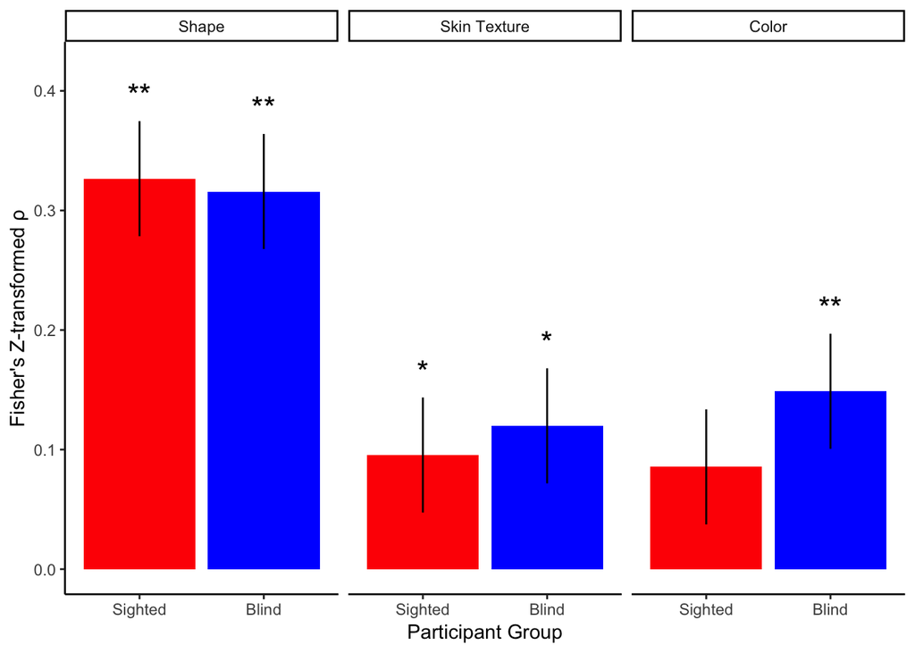

```r
ggplot(cor_df, aes(x = fct_rev(participant_type), y = estimate, fill = participant_type)) +
  geom_bar(stat = "identity", position = "dodge") +
  facet_grid(~dimension, drop = T, scales="free_x",space = "free_x") +
  ylab("Fisher's \u0396-transformed \u03C1") +
  xlab("Participant Group") +
  ylim(0, .42) +
  geom_text(aes(y = estimate + .07, label = sig), size = 6) +
  geom_linerange(aes(ymin = estimate_se_l, ymax = estimate_se_h)) +
  theme_classic() +
  scale_fill_manual(values = c("blue", "red")) +
  theme(legend.position = "none")
```

# Google News

```r
LANG_ANIMAL_DISTANCE_COLOR <- here("data/processed/animal_color_distances_language_google.csv")
LANG_ANIMAL_DISTANCE_SHAPE <- here("data/processed/animal_shape_distances_language_google.csv")
LANG_ANIMAL_DISTANCE_TEXTURE <- here("data/processed/animal_texture_distances_language_google.csv")

TIDY_HUMAN_PATH <- here("data/processed/tidy_human_data.csv")
language_data <- read_csv(LANG_ANIMAL_DISTANCE_COLOR) %>%
  left_join(read_csv(LANG_ANIMAL_DISTANCE_SHAPE), by  = c("animal1", "animal2")) %>%
  left_join(read_csv(LANG_ANIMAL_DISTANCE_TEXTURE),by  = c("animal1", "animal2"))

human_data <- read_csv(TIDY_HUMAN_PATH)
full_sim_data <- full_join(language_data, human_data, by = c("animal1", "animal2"))

human_data_wide <- human_data %>%
  unite("measure", c("participant_type", "similarity_type")) %>%
  spread(measure, human_similarity)
full_sim_data_wide <- full_join(language_data, human_data_wide,
                                by = c("animal1", "animal2"))%>%
  full_join(taxonomic_long)  %>%
  filter(animal1 < animal2)
```

Replication on a second corpus.

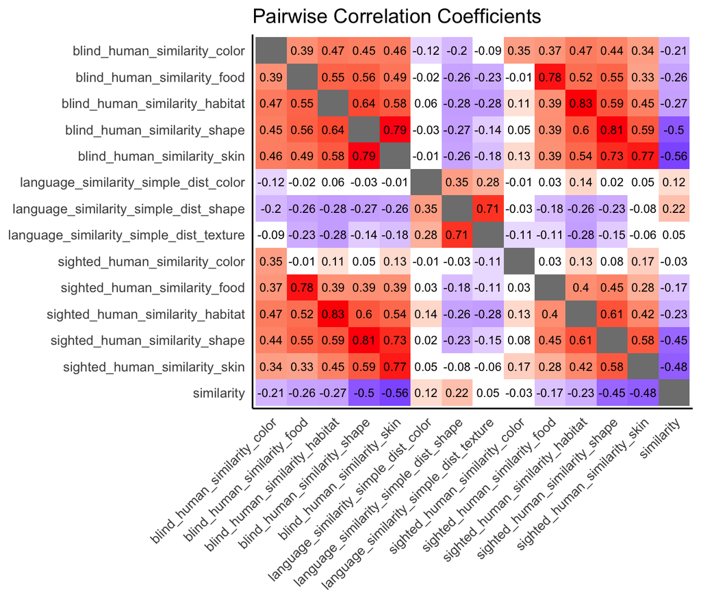

```r
plot_data <- full_sim_data_wide %>%
  select_if(is.numeric)

long_corr <- cor(plot_data,
                 use = "pairwise.complete.obs",
                 method = "spearman") %>%
  as.data.frame() %>%
  rownames_to_column("v2") %>%
  gather("v1", "estimate", -v2)

long_p <- corrplot::cor.mtest(plot_data,
                              use = "pairwise.complete.obs",
                              method = "spearman")$p %>%
  as.data.frame(row.names = names(plot_data)) %>%
  do(setNames(.,names(plot_data))) %>%
  rownames_to_column("v2") %>%
  gather("v1", "p", -v2)
corr_df <- full_join(long_corr, long_p) %>%
  mutate(estimate_char = case_when(v1 == v2 ~ "",
                                   TRUE ~ as.character(round(estimate,2))),
         estimate = case_when(v1 == v2 ~ as.numeric(NA),
                              TRUE ~ estimate),
         estimate_color = case_when(p < .05 ~ estimate, TRUE ~ 0 ))

ggplot(corr_df, aes(v1, fct_rev(v2), fill = estimate_color)) +
  geom_tile() + #rectangles for each correlation
  #add actual correlation value in the rectangle
  geom_text(aes(label = estimate_char), size=3) +
  scale_fill_gradient2(low ="blue", mid = "white", high = "red",
                       midpoint = 0, space = "Lab", guide = "colourbar",
                       name = "Pearson's r") +
  ggtitle("Pairwise Correlation Coefficients") +
  theme_classic(base_size = 12) +
  theme(axis.text.x = element_text(angle = 45, hjust = 1), #, hjust = .95, vjust = .2),
        axis.title.x=element_blank(),
        axis.title.y=element_blank(),
        axis.ticks = element_blank(),
        legend.position = "none")
```